# riskyr user guide

Hansjörg Neth, SPDS, uni.kn

2025-11-05

> “Solving a problem simply means representing it so as to make the solution transparent.”  
> (H.A. Simon)[^1]

What is the probability of a disease or clinical condition given a positive test result? This is a common and fairly simple question, yet doctors, patients and medical students find it surprisingly difficult to answer.

Decades of research on probabilistic reasoning and risk literacy have shown that people are perplexed and struggle when information is expressed in terms of probabilities (e.g., see Mandel & Navarrete, 2015, and Trevethan, 2017, for overviews), but find it easier to understand and process the same information when it is expressed in terms of natural frequencies (see Gigerenzer and Hoffrage, 1995; Gigerenzer et al., 2007; Hoffrage et al., 2015).

**riskyr** is a toolbox for rendering risk literacy more transparent by facilitating such changes in representation and offering multiple perspectives on the dynamic interplay between frequencies and probabilities. The main goal of **riskyr** is to provide a long-term boost in risk literacy by fostering competence in understanding statistical information in different applied domains (Hertwig & Grüne-Yanoff, 2017). Although our motivation and the majority of our examples stem from health care and medical treatments, the same relationships and tasks also govern the interplay of risks and effects in other semantic domains (e.g., accidents, climate and weather risks, or financial risks).

This guide illustrates a typical problem and then helps you solving it by viewing risk-related information in a variety of ways. It proceeds in three steps:

1. We first present the problem in the probabilistic format that is commonly used in textbooks. This allows introducing some key probabilities, but also explains why both this problem and its traditional solution (via Bayes’ theorem) remains opaque and is rightfully perceived as difficult.
2. We then translate the problem into natural frequencies and show how this facilitates its comprehension and solution.
3. Finally, **riskyr** helps rendering problems more transparent by providing three sets of tools:

   A. Functions for computing probabilities and frequencies;

   B. Functions for translating between different representational formats;

   C. Visualizations that illustrate relationships between frequencies and probabilities.

This introduction focuses on the practical aspects of using **riskyr**. The theoretical background is illuminated further in the following article:

- Neth, H., Gradwohl, N., Streeb, D., Keim, D.A., & Gaissmaier, W. (2021). Perspectives on the 2x2 matrix: Solving semantically distinct problems based on a shared structure of binary contingencies. *Frontiers in Psychology*, *11*, 567817. doi: 10.3389/fpsyg.2020.567817

## Motivation: A problem of probabilities

A basic motivation for developing **riskyr** was to facilitate our understanding of problems like the following:

> **Mammography screening**

> The probability of breast cancer is 1% for a woman at age 40 who participates in routine screening. If a woman has breast cancer, the probability is 80% that she will get a positive mammography. If a woman does not have breast cancer, the probability is 9.6% that she will also get a positive mammography.

> A woman in this age group had a positive mammography in a routine screening.  
> What is the probability that she actually has breast cancer?

> (Hoffrage et al., 2015, p. 3)

### Information provided and asked

Problems like this tend to appear in texts and tutorials on risk literacy and are ubiquitous in medical diagnostics. They typically provide some risk-related information (i.e., specific probabilities of some clinical condition and likelihoods of some decision or test of detecting its presence or absence) and ask for some other risk-related quantity. In the most basic type of scenario, we are given 3 essential probabilities:

1. The *prevalence* of some target population (here: women at age 40) for some condition (breast cancer):
- `prev` = $p(\mathrm{cancer}) = 1\%$
2. The *sensitivity* of some decision or diagnostic procedure (here: a mammography screening test), which is the conditional probability:
- `sens` = $p(\mathrm{positive\ test}\ |\ \mathrm{cancer}) = 80\%$
3. The *false alarm rate* of this decision, diagnostic procedure or test, which is the conditional probability:
- `fart` = $p( \mathrm{positive\ test}\ |\ \mathrm{no\ breast\ cancer} ) = 9.6\%$

and can also be expressed by its complement (aka. the test’s *specificity*):

- `spec` = 1 – `fart` = $p( \mathrm{negative\ test}\ |\ \mathrm{no\ cancer} ) = 90.4\%$

The first challenge in solving this problem is to realize that the probability asked for is *not* the sensitivity `sens` (i.e., the probability of a positive test given cancer), but the *reversed* conditional probability (i.e., the probability of having cancer given a positive test). The clinical term for this quantity is the *positive predictive value* (`PPV`) or the test’s *precision*:

- `PPV` = $p( \mathrm{cancer}\ |\ \mathrm{positive\ test} )$ = ?

How can we compute the *positive predictive value* (`PPV`) from the information provided by the problem? In the following, we sketch three different paths to the solution.

### Using Bayes’ theorem

One way to solve problems concerning conditional probabilities is to remember and apply Bayes’ theorem (which is why such problems are often called problems of “Bayesian reasoning”):

$$p(H|D) = \frac{p(H) \cdot p(D|H) }
{p(H) \cdot p(D|H) + p(\neg H) \cdot p(D|\neg H) }$$

In our example, we are asking for the conditional probability of breast cancer ($H$) given a positive mammography test ($D$):

$$p(\mathrm{cancer}\ |\ \mathrm{positive\
test})
= \frac{p(\mathrm{cancer}) \cdot p(\mathrm{positive\ test}\ |\
\mathrm{cancer}) }
{p(\mathrm{cancer}) \cdot p(\mathrm{positive\ test}\ |\
\mathrm{cancer}) +
p(\mathrm{no\ cancer}) \cdot p(\mathrm{positive\ test}\ |\ \mathrm{no\
cancer}) }$$

or, when using $C$ as denoting cancer and $T$ as denoting a positive test:

$$p(C|T) = \frac{p(C) \cdot p(T|C) }
{p(C) \cdot p(T|C) + p(\neg C) \cdot p(T|\neg C) }$$

By inserting the probabilities identified above and knowing that the probability for the absence of breast cancer in our target population is the complementary probability of its presence (i.e., $p$(no cancer) = 1 – `prev` = 99%) we obtain:

$$p(\mathrm{cancer}\ |\ \mathrm{positive\
test})
= \frac{1\% \cdot 80\% }
{ 1\% \cdot 80\% +
99\% \cdot 9.6\% } \approx\ 7.8\%$$

Thus, the information above and a few basic mathematical calculations tell us that the likelihood of a woman in our target population with a positive mammography screening test actually having breast cancer (i.e., the `PPV` of this mammography screening test for this population of women) is slightly below 8%.

## Using natural frequencies

If you fail to find the Bayesian solution easy and straightforward, you are in good company: Even people who have studied and taught statistics often find it difficult to think in these terms. Fortunately, researchers have discovered that a simple change in representation renders the same information much more transparent.

Consider the following problem description:

> **Mammography screening** (`freq`)

> 10 out of every 1000 women at age 40 who participate in routine screening have breast cancer.  
> 8 out of every 10 women with breast cancer will get a positive mammography.  
> 95 out of every 990 women without breast cancer will also get a positive mammography.

> Here is a new representative sample of women at age 40 who got a positive mammography in a routine screening.  
> How many of these women do you expect to actually have breast cancer?

> (Hoffrage et al., 2015, p. 4)

Importantly, this version (freq) of the problem refers to a frequency of $1000$ individuals of our original target population. It still provides the same probabilities as above, but specifies them in terms of *natural frequencies* (see Gigerenzer & Hoffrage, 1999, and Hoffrage et al., 2002, for clarifications of this concept):

1. The *prevalence* of breast cancer in the target population:
- `prev` = $p(\mathrm{cancer}) = \frac{10}{1000} (= 1\%)$
2. The *sensitivity* of the mammography screening test, which is the conditional probability:
- `sens` = $p(\mathrm{positive\ test}\ |\ \mathrm{cancer}) = \frac{8}{10} (= 80\%)$
3. The test’s *false alarm rate*, which is the conditional probability:
- `fart` = $p( \mathrm{positive\ test}\ |\ \mathrm{no\ breast\ cancer} ) = \frac{95}{990} (\approx\ 9.6\%)$

and can still be expressed by its complement (the test’s *specificity*):

- `spec` = 1 – `fart` = $p( \mathrm{negative\ test}\ |\ \mathrm{no\ cancer} ) = \frac{990 - 95}{990} = \frac{895}{990} (\approx\ 90.4\%)$

Rather than asking us to compute a conditional probability (i.e., the `PPV`), the task now prompts us to imagine a new representative sample of women from our target population and focuses on the women with a positive test result. It then asks for a *frequency* as a subset of a population: “How many of these women” do we expect to have cancer?

To provide any answer in terms of frequencies, we need to imagine a specific population or sample size $N$. As the problem referred to a population of $1000$ women, we conveniently pick a sample size of $N = 1000$ women with identical characteristics (which is suggested by mentioning a “representative” sample) and ask: How many women with a positive test result actually have cancer?[^2]

## Using riskyr

Reframing the probabilistic problem in terms of frequencies made its solution easier. This is neat and probably one of the best tricks in risk literacy education (as advocated by Gigerenzer & Hoffrage, 1995; Gigerenzer 2002; 2014). While it is good to have a way to *cope* with tricky problems, it would be even more desirable to *actually understand* the interplay between probabilities and frequencies in risk-related tasks and domains. This is where **riskyr** comes into play.[^3]

**riskyr** provides a set of basic risk literacy tools in R. As we have seen, the problems humans face when dealing with risk-related information are less of a *computational*, and more of a *representational* nature. As a statistical programming language, R is a pretty powerful computational tool, but for our present purposes it is more important that R is also great for designing and displaying aesthetic and informative visualizations. By applying these qualities to the task of training and instruction in risk literacy, **riskyr** is a toolbox that renders risk literacy education more transparent.

### Risk vs. uncertainty

To clarify the concept of “risk” used in this context: In both basic research on the psychology of judgment and decision making and more applied research on risk perception and risk communication, the term *risk* refers to information or decisions for which all options and their consequences are known and *probabilities* for the different outcomes can be provided. This notion of *risk* is typically contrasted with the wider notion of *uncertainty* in which options or probabilities are unknown or cannot be quantified.[^4]

For our present purposes, the notion of risk-related information refers to any scenario in which some events are determined by probabilities. A benign example of a risk-related situation is the **riskyr** start-up message: Every time you load the package, the dice are cast and determine which particular message (out of a range of possible messages) is shown. Even if you notice this, determining the exact probability of a message would require extensive experience, explicit information (e.g., us telling you that we use R’s `sample` function to randomly select 1 of 5 possible messages), or cheating (by peeking at the source code). In real life, the events of interest are vastly more complex and numerous and both our experience and options for cheating are subject to hard constraints. Thus, provided we do not want to regress into superstition, we need science to figure out probabilities and transparent risk communication for understanding them.

### Promoting risk perception and communication

**riskyr** facilitates risk perception and promotes a deeper understanding of risk-related information in three ways:[^5]

- by organizing *data structures* and *computational functions* in useful ways;
- by providing *translations* between probabilities and frequencies;
- by providing transparent *visualizations* that illustrate relationships between variables and representations.

If others find the ways in which **riskyr** computes, transforms, and represents risks helpful or useful, **riskyr** may facilitate teaching and training efforts in risk literacy and generally hopes to promote a more transparent communication of risk-related information. In the following, we show how we can address the above problem by using three types of tools provided by **riskyr**.

### A. A fancy calculator

**riskyr** provides a set of functions that allows us to calculate various desired outputs (probabilities and frequencies) from given inputs (probabilities and frequencies). For instance, the following function computes the positive predictive value `PPV` from the 3 essential probabilities `prev`, `sens`, and `spec` (with `spec` = 1 – `fart`) that were provided in the original problem:

```r
library("riskyr")  # loads the package

comp_PPV(prev = .01, sens = .80, spec = (1 - .096))
```

```
#> [1] 0.07763975
```

It’s good to know that **riskyr** can apply Bayes’ formula, but so can any other decent calculator — including my brain on a good day and some environmental support in the form of paper and pencil. The R in **riskyr** only begins to make sense when considering functions like the following: `comp_prob_prob()` computes probabilities from probabilities (hence its name). More precisely, `comp_prob_prob()` takes three essential probabilities as inputs and returns a list of 13 probabilities as its output:

```r
# Compute probabilities from 3 essential probabilities:                 # Input arguments:
p1 <- comp_prob_prob(prev = .01, sens = .80, spec =   NA, fart = .096)  # prev, sens, NA,   fart
p2 <- comp_prob_prob(prev = .01, sens = .80, spec = .904, fart =   NA)  # prev, sens, spec, NA
p3 <- comp_prob_prob(prev = .01, sens = .80, spec = .904, fart = .096)  # prev, sens, spec, fart

# Check equality of outputs:
all.equal(p1, p2)
```

```
#> [1] TRUE
```

```r
all.equal(p2, p3)
```

```
#> [1] TRUE
```

The probabilities provided need to include a prevalence `prev`, a sensitivity `sens`, and either the specificity `spec` or the false alarm rate `fart` (with `spec` = 1 – `fart`). The code above illustrates 3 different ways in which 3 of these “essential” probabilities can be provided. Thus, the assigned objects `p1`, `p2`, and `p3`, are all equal to each other.

```r
unlist(p1)
```

```
#>        prev        sens        mirt        spec        fart        ppod
#> 0.010000000 0.800000000 0.200000000 0.904000000 0.096000000 0.103040000
#>         PPV         FDR         NPV         FOR         acc    p_acc_hi
#> 0.077639752 0.922360248 0.997770246 0.002229754 0.902960000 0.008859750
#>    p_err_fa
#> 0.979389942
```

The list of probabilities computed includes the 3 essential probabilities (`prev`, `sens`, and `spec` or `fart`) and the desired probability (`p1$PPV` = 0.0776398), but also many other probabilities that may have been asked instead. (The selection of 13 probabilities include the most prominent candidate measures, but the Bayesian situation supports many additional probabilities. Which of them are considered is largely a matter of perspective. See the vignette on data formats for details, and [Neth et al., 2021](https://doi.org/10.3389/fpsyg.2020.567817) for the theoretical background.)

Incidentally, as R does not care whether probabilities are entered as decimal numbers or fractions, we can check whether the 2nd version of our problem — the version reframed in terms of frequencies — yields the same solution:

```r
# Compute probabilities from 3 ratios of frequencies (probabilities):       # Input arguments:
p4 <- comp_prob_prob(prev = 10/1000, sens = 8/10, spec = NA, fart = 95/990) # prev, sens, NA, fart

p4$PPV
```

```
#> [1] 0.0776699
```

This shows that the `PPV` computed by this version is only marginally different (`p4$PPV` = 0.0776699). More importantly, it is identical to the ratio $\frac{8}{103}$ = 0.0776699.

### B. Translating between formats

Another function of **riskyr** is to translate between representational formats. This translation comes in two varieties:

#### Computing frequencies from probabilities

The `comp_freq_prob()` function computes desired frequencies from given probabilities:

```r
# Compute frequencies from probabilities:
f1 <- comp_freq_prob(prev =     .01, sens =  .80, spec = NA, fart =   .096, N = 1000)
f2 <- comp_freq_prob(prev = 10/1000, sens = 8/10, spec = NA, fart = 95/990, N = 1000)

# Check equality of outputs:
all.equal(f1, f2)
```

```
#> [1] TRUE
```

To compute a set of frequencies for the specific sample size of 1000 individuals, we need to provide `N = 1000` as an additional argument. As before, it does not matter whether the probabilities are supplied as decimal numbers or as ratios (as long as they actually *are* probabilities, i.e., numbers ranging from 0 to 1).

```r
# Compute frequencies from probabilities (without rounding):
f3 <- comp_freq_prob(prev =     .01, sens =  .80, spec = NA, fart =   .096, N = 1000, round = FALSE)
f4 <- comp_freq_prob(prev = 10/1000, sens = 8/10, spec = NA, fart = 95/990, N = 1000, round = FALSE)

## Check equality of outputs:
all.equal(f3, f4)  # => shows slight differences in some frequencies:
```

[output not shown]

As before, `comp_freq_prob()` does not compute just one frequency, but a list of 11 frequencies. Their names and values can be inspected by printing `f1` (as a vector):

```r
unlist(f1)
```

```
#>          N  cond_true cond_false    dec_pos    dec_neg    dec_cor    dec_err
#>       1000         10        990        103        897        903         97
#>         hi         mi         fa         cr
#>          8          2         95        895
```

#### Computing probabilities from frequencies

A translator between 2 representational formats should work in both directions. Consequently, **riskyr** also allows to compute probabilities by providing frequencies:

```r
# Compute probabilities from frequencies:
p5 <- comp_prob_freq(hi = 8, mi = 2, fa = 95, cr = 895)  # => provide 4 essential frequencies
```

Fortunately, the `comp_prob_freq` does not require all 11 frequencies that were returned by `comp_freq_prob` and contained in the list of frequencies `f1`. Instead, we must provide `comp_prob_freq` with the 4 essential frequencies that were listed as `hi`, `mi`, `fa`, and `cr` in `f1`. The resulting probabilities (saved in `p5`) match our list of probabilities from above (saved in `p4`):

```r
# Check equality of outputs:
all.equal(p5, p4)
```

[output not shown]

#### Switching back and forth

More generally, when we translate between formats twice — first from probabilities to frequencies and then from the resulting frequencies to probabilities — the original probabilities appear again:

```r
# Pick 3 random probability inputs:
rand.p <- runif(n = 3, min = 0, max = 1)
rand.p

# Translation 1: Compute frequencies from probabilities (without rounding):
freq <- comp_freq_prob(prev = rand.p[1], sens = rand.p[2], spec = rand.p[3], round = FALSE)

# Translation 2: Compute probabilities from frequencies:
prob <- comp_prob_freq(hi = freq$hi, mi = freq$mi, fa = freq$fa, cr = freq$cr)

## Verify that results match original probabilities:
all.equal(prob$prev, rand.p[1])
all.equal(prob$sens, rand.p[2])
all.equal(prob$spec, rand.p[3])
```

Similarly, going full circle from frequencies to probabilities and back returns the original frequencies:

```r
# Pick 4 random frequencies:
rand.f <- round(runif(n = 4, min = 0, max = 10^3), 0)
rand.f
# sum(rand.f)

# Translation 1: Compute probabilities from frequencies:
prob <- comp_prob_freq(hi = rand.f[1], mi = rand.f[2], fa = rand.f[3], cr = rand.f[4])
# prob

# Translation 2: Compute frequencies from probabilities (for original N, without rounding):
freq <- comp_freq_prob(prev = prob$prev, sens = prob$sens, spec = prob$spec,
                       N = sum(rand.f), round = FALSE)
# freq

# Verify that results match original frequencies:
all.equal(freq$hi, rand.f[1])
all.equal(freq$mi, rand.f[2])
all.equal(freq$fa, rand.f[3])
all.equal(freq$cr, rand.f[4])
```

To obtain the same results when translating back and forth between probabilities and frequencies, it is important to switch off rounding when computing frequencies from probabilities with `comp_freq_prob`. Similarly, we need to scale the computed frequencies to the original population size `N` to arrive at the original frequencies.

#### All at once: Defining a `riskyr` scenario

In the likely case that you are less interested in specific metrics or formats and only want to get a quick overview of the key variables of a risk-related situation, you can always define a `riskyr` scenario:

```r
s <- riskyr(scen_lbl = "Mammography screening",
            cond_lbl = "breast cancer",
            cond_true_lbl = "cancer", cond_false_lbl = "no cancer",
            dec_lbl = "screening test",
            dec_pos_lbl = "predict cancer", dec_neg_lbl = "predict no cancer",
            prev = .01,
            sens = .80,
            spec = NA,
            fart = .096)
```

Using the **riskyr** function `riskyr()` defined a new scenario `s` and initialized it with a suitable population size of `N = 1000`. Use the `summary` command to get an overview over its key parameters:

```r
summary(s)  # provides an overview over key scenario information:
```

```
#> Scenario:  Mammography screening
#>
#> Condition:  breast cancer
#> Decision:  screening test
#> Population:  Population
#> N =  1000
#> Source:  Source information
#>
#> Probabilities:
#>
#>  Essential probabilities:
#>  prev  sens  mirt  spec  fart
#> 0.010 0.800 0.200 0.904 0.096
#>
#>  Other probabilities:
#>  ppod   PPV   NPV   FDR   FOR   acc
#> 0.103 0.078 0.998 0.922 0.002 0.903
#>
#> Frequencies:
#>
#>  by conditions:
#>  cond_true cond_false
#>         10        990
#>
#>  by decision:
#> dec_pos dec_neg
#>     103     897
#>
#>  by correspondence (of decision to condition):
#> dec_cor dec_err
#>     903      97
#>
#>  4 essential (SDT) frequencies:
#>  hi  mi  fa  cr
#>   8   2  95 895
#>
#> Accuracy:
#>
#>  acc:
#> 0.90296
```

The fastest way to get an overview over a scenario `s` is by plotting it:

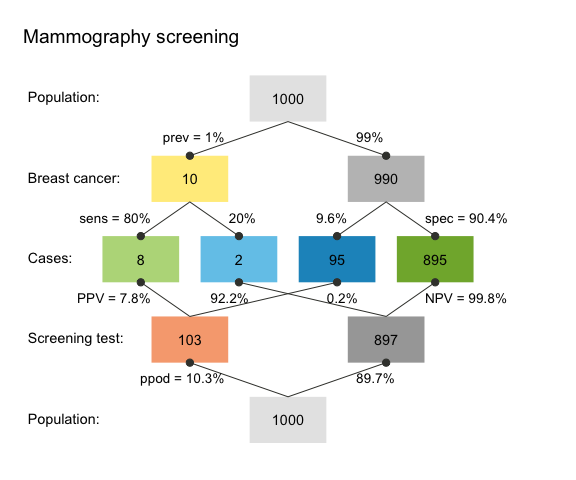

```r
plot(s)  # a prism/network diagram of key frequencies and probabilities (by default):
```

The default plot used by **riskyr** when not specifying a desired plot type is a so-called *prism* plot (aka. double tree). However, there are many other types of plots and customization options available. In the following, we explain different visualizations by introducing their corresponding plotting functions. For the impatient: The Quick start primer explains how to directly plot different visualizations of a given scenario.

### C. Visualizing relationships between formats and variables

Inspecting the lists of probabilities and frequencies shows that the two problem formulations cited above are only two possible instances out of an array of many alternative formulations. Essentially, the same scenario can be described in a variety of variables and formats. Gaining deeper insights into the interplay between these variables requires a solid understanding of the underlying concepts and their mathematical definitions. To facilitate the development of such an understanding, **riskyr** recruits the power of visual representations and shows the same scenario from a variety of angles and perspectives. It is mostly this graphical functionality that supports **riskyr**’s claim on being a toolbox for rendering risk literacy more transparent. Thus, in addition to being a fancy calculator and a translator between formats, **riskyr** is mostly a machine that turns risk-related information into pretty pictures.

**riskyr** provides many alternative visualizations that depict the same risk-related scenario in the form of different representations. As each type of graphic has its own properties and perspective — strengths that emphasize or illuminate some particular aspect and weaknesses that hide or obscure others — the different visualizations are somewhat redundant, yet complement and support each other.[^6]

Here are some examples that depict particular aspects of the scenario described above:

#### Icon array

A straightforward way of plotting an entire population of individuals is provided by an *icon array* that represents each individual as a symbol which is color-coded:

```
#> Argument 'title_lbl' is deprecated. Please use 'main' instead.
```

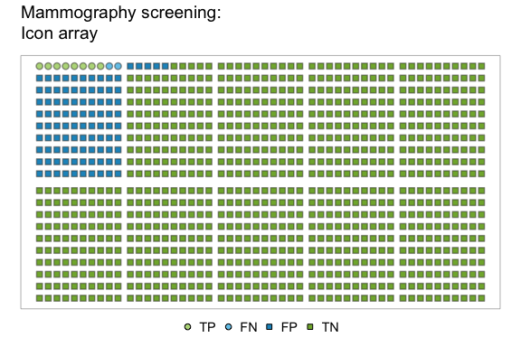

An icon array showing the mammography scenario for a population of 1000 individuals.

```r
plot_icons(prev = .01, sens = .80, spec = NA, fart = .096, N = 1000,
           icon_types = c(21, 21, 22, 22),
           title_lbl = "Mammography screening")
```

#### Tree diagram

Perhaps the most intuitive visualization of the relationships between probability and frequency information in our above scenario is provided by a *tree* diagram that shows the population and the frequency of subgroups as its nodes and the probabilities as its edges:

```
#> Argument 'title_lbl' is deprecated. Please use 'main' instead.
```

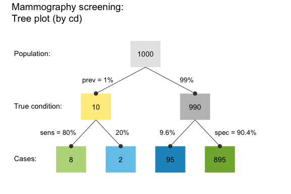

A tree diagram that applies the provided probabilities and frequencies to a population of 1000 individuals.

```r
plot_prism(prev = .01, sens = .80, spec = NA, fart = .096, N = 1000,
           by = "cd", title_lbl = "Mammography screening")
```

Importantly, the `plot_prism()` function plot a simple frequency tree when providing a single perspective argument `by = "cd"` (as opposed to its default `by = "cddc"`). Here, it is called with the same 3 essential probabilities (`prev`, `sens`, and `spec`) and 1 frequency (the number of individuals `N` of our sample or population). But in addition to computing risk-related information (e.g., the number of individuals in each of the 4 subgroups at the 2nd level of the tree), the tree diagram visualizes crucial dependencies and relationships between frequencies and probabilities. For instance, the diagram illustrates that the number of true positives (`hi`) depends on both the condition’s prevalence (`prev`) and the decision’s sensitivity (`sens`), or that the decision’s specificity `spec` can be expressed and computed as the ratio of the number of true negatives (`cr`) divided by the number of unaffected individuals (`cond_false` cases).

#### Area plot

An alternative way to split a group of individuals into subgroups depicts the population as a square and dissects it into various rectangles that represent parts of the population. In the following *area* plot (aka. *mosaic* plot), the relative proportions of rectangle sizes represent the relative frequencies of the corresponding subgroups:

```
#> Argument 'title_lbl' is deprecated. Please use 'main' instead.
```

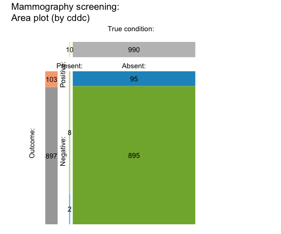

An area plot in which area sizes represent the probabilities/relative frequencies of subgroups.

```r
plot_area(prev = .01, sens = .80, spec = NA, fart = .096, N = 1000,
          title_lbl = "Mammography screening")
```

The vertical split dissects the population into two subgroups that correspond to the frequency of `cond_true` and `cond_false` cases in the tree diagram above. The `prev` value of 1% yields a slim vertical rectangle on the left. (For details and additional options of the `plot_area` function, see the documentation of `?plot_area`.)

#### Bar plot

The tree diagrams from above can also be depicted as a vertical bar plot:

```r
plot_bar(prev = .01, sens = .80, spec = NA, fart = .096, N = 1000,
         by = "all", dir = 2, title_lbl = "Mammography screening")
```

(The plot is not shown here, but please go ahead and create it for yourself.)

However, due to a number of categories with a very low number of members, many bars are barely visible (which is why they are not shown here).

#### Prism plot

The *prism* plot (called network diagram in version 0.1.0 of **riskyr**) is a generalization of the *tree* diagram (see Wassner et al., 2004). It plots 9 different frequencies (computed by `comp_freq_prop()` and `comp_freq_freq()` and contained in `freq`) as nodes of a single graph and depicts 12 probabilities (computed by `comp_prop_prop()` and `comp_prop_freq()` and contained in `prob`) as edges between these nodes. Thus, the prism diagram provides two distinct perspectives on the four frequencies in its center row. By scaling nodes by either frequency or probability, **riskyr** visualizes the interplay of frequencies and probabilities in a variety of ways:

```
#> Argument 'title_lbl' is deprecated. Please use 'main' instead.
```

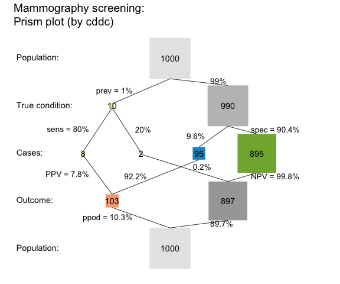

A prism plot that integrates 2 tree diagrams and represents relative frequency by area size.

```r
plot_prism(prev = .01, sens = .80, spec = NA, fart = .096, N = 1000,
           by = "cddc", area = "sq", title_lbl = "Mammography screening")
```

Changing the `by` and `area` options provides a variety of perspectives on a scenario. Additionally, all plotting functions provide summary information on scenario parameters and current accuracy metrics on the lower margin. Setting `mar_notes = FALSE` gets rid of this display. Similarly, setting `scen_lbl = ""` removes the title and sub-title above the plot.

#### Alternative perspectives

The variety of different graphical options provided by **riskyr** can be overwhelming at first — but fortunately the default options work reasonably well in most cases. In the following, we illustrate some additional parameters and points, and trust that you can evaluate and explore the corresponding commands yourself.

Both the tree/prism diagrams and the mosaic plots shown above adopted a particular perspective by splitting the population into 2 subgroups by condition (via the default option `by = "cd"`). Rather than emphasizing the difference between `cond_true` and `cond_false` cases, an alternative perspective could ask: How many people are detected as positive vs. negative by the test? By using the option `by = "dc"`, the tree diagram splits the population by decisions into `dec_pos` and `dec_neg` cases:

```r
plot_prism(prev = .01, sens = .80, spec = NA, fart = .096, N = 1000,
           by = "dc", title_lbl = "Mammography screening", col_pal = pal_mod)
```

(Note that using the `col_pal` argument changed the color scheme to the pre-defined `pal_mod` color palette.)

Similarly, we can plot a tree diagram that splits the population by accuracy into cases of TRUE and FALSE (`dec_cor` and `dec_err`) decisions:

```r
plot_prism(prev = .01, sens = .80, spec = NA, fart = .096, N = 1000,
           by = "ac", title_lbl = "Mammography screening")
```

The same perspectives can also be applied to other plots. For instance, the population of the area/mosaic plot can first be split by decisions (i.e., horizontally) by specifying the options `by = "cddc"` and `p_split = "h"`:

```r
plot_area(prev = .01, sens = .80, spec = NA, fart = .096, N = 1000,
          by = "cddc",    # show by condition x decision
          p_split = "h",  # horizontal perspective is primary
          title_lbl = "Mammography screening")
```

**riskyr** uses a consistent color scheme to represent the same subgroups across different graphs. If this color coding is not sufficient, plotting the tree diagram with the option `area = "hr"` further highlights the correspondence by representing the relative frequencies of subgroups by the proportions of rectangles:

```r
plot_prism(prev = .01, sens = .80, spec = NA, fart = .096, N = 1000,
           by = "dc", area = "hr", title_lbl = "Mammography screening")
```

Incidentally, as both an icon array and a mosaic plot depict probability by area size, both representations can be translated into each other. Even when relaxing the positional constraint of icons in the icon array, the similarity is still visible:

```r
plot_icons(prev = .01, sens = .80, spec = NA, fart = .096, N = 1000,
           arr_type = "mosaic", icon_types = c(21, 21, 22, 22), icon_size = 2,
           title_lbl = "Mammography screening")
```

Can you spot cases of hits (true positives) and misses (false negatives)? (Hint: Their frequency is 8 and 2, respectively.)

For more details, see the documentation and examples of the visualization functions (e.g., `plot_area()`, `plot_icons()`, and `plot_prism()`).

## References

- Gigerenzer, G. (2002). *Reckoning with risk: Learning to live with uncertainty*. London, UK: Penguin.
- Gigerenzer, G. (2014). *Risk savvy: How to make good decisions*. New York, NY: Penguin.
- Gigerenzer, G., & Gaissmaier, W. (2011). Heuristic decision making. *Annual Review of Psychology*, *62*, 451–482. ([Available online](https://doi.org/10.1146/annurev-psych-120709-145346))
- Gigerenzer, G., Gaissmaier, W., Kurz-Milcke, E., Schwartz, L., & Woloshin, S. (2007). Helping doctors and patients make sense of health statistics. *Psychological Science in the Public Interest*, *8*, 53–96. ([Available online](https://doi.org/10.1111/j.1539-6053.2008.00033.x))
- Gigerenzer, G., & Hoffrage, U. (1995). How to improve Bayesian reasoning without instruction: Frequency formats. *Psychological Review*, *102*, 684–704.
- Gigerenzer, G., & Hoffrage, U. (1999). Overcoming difficulties in Bayesian reasoning: A reply to Lewis and Keren (1999) and Mellers and McGraw (1999). *Psychological Review*, *106*, 425–430.
- Hertwig, R., & Grüne-Yanoff, T. (2017). Nudging and boosting: Steering or empowering good decisions. *Perspectives on Psychological Science*, *12*, 973–986.
- Hoffrage, U., Gigerenzer, G., Krauss, S., & Martignon, L. (2002). Representation facilitates reasoning: What natural frequencies are and what they are not. *Cognition*, *84*, 343–352.
- Hoffrage, U., Krauss, S., Martignon, L., & Gigerenzer, G. (2015). Natural frequencies improve Bayesian reasoning in simple and complex inference tasks. *Frontiers in Psychology*, *6*, 1473. ([Available online](https://doi.org/10.3389/fpsyg.2015.01473))
- Hoffrage, U., Lindsey, S., Hertwig, R., & Gigerenzer, G. (2000). Communicating statistical information. *Science*, *290*, 2261–2262.
- Khan, A., Breslav, S., Glueck, M., & Hornbæk, K. (2015). Benefits of visualization in the mammography problem. *International Journal of Human-Computer Studies*, *83*, 94–113.
- Kurzenhäuser, S., & Hoffrage, U. (2002). Teaching Bayesian reasoning: An evaluation of a classroom tutorial for medical students. *Medical Teacher*, *24*, 516–521.
- Kurz-Milcke, E., Gigerenzer, G., & Martignon, L. (2008). Transparency in risk communication. *Annals of the New York Academy of Sciences*, *1128*, 18–28.
- Mandel, D. R. & Navarrete, G. (2015). Editorial: Improving Bayesian reasoning: What works and why? *Frontiers in Psychology*, *6*, 1872. ([Available online](https://doi.org/10.3389/fpsyg.2015.01872))
- Micallef, L., Dragicevic, P., & Fekete, J.-D. (2012). Assessing the effect of visualizations on Bayesian reasoning through crowd-sourcing. *IEEE Transactions on Visualization and Computer Graphics*, *18*, 2536–2545.
- Neth, H., & Gigerenzer, G. (2015). Heuristics: Tools for an uncertain world. In R. Scott & S. Kosslyn (Eds.), *Emerging trends in the social and behavioral sciences*. New York, NY: Wiley Online Library. doi: 10.1002/9781118900772.etrds0394 ([Available online](https://neth.de/wordpress/wp-content/uploads/2015/04/NethGigerenzer15_Heuristics_ToolsUncertainty_EmergingTrends0394.pdf))
- Neth, H., Gradwohl, N., Streeb, D., Keim, D.A., & Gaissmaier, W. (2021). Perspectives on the 2x2 matrix: Solving semantically distinct problems based on a shared structure of binary contingencies. *Frontiers in Psychology: Cognition*, *11*, 567817. doi: 10.3389/fpsyg.2020.567817 ([Available online](https://doi.org/10.3389/fpsyg.2020.567817))
- Sedlmeier, P., & Gigerenzer, G. (2001). Teaching Bayesian reasoning in less than two hours. *Journal of Experimental Psychology: General*, *130*, 380–400.
- Strevens, M. (2013). *Tychomancy: Inferring probability from causal structure*. Cambridge, MA: Harvard University Press.
- Trevethan, R. (2017). Sensitivity, specificity, and predictive values: Foundations, pliabilities, and pitfalls in research and practice. *Frontiers in Public Health*, *5*, 307. ([Available online](https://doi.org/10.3389/fpubh.2017.00307))
- Wassner, C., Martignon, L., & Biehler, R. (2004). Bayesianisches Denken in der Schule. *Unterrichtswissenschaft*, *32*, 58–96.

### Resources

The following resources and versions are currently available:

| Type: | Version: | URL: |
| --- | --- | --- |
| A. **riskyr** (R package): | [Release version](https://CRAN.R-project.org/package=riskyr) | https://CRAN.R-project.org/package=riskyr |
|  | [Development version](https://github.com/hneth/riskyr/) | https://github.com/hneth/riskyr/ |
| B. **riskyrApp** (R Shiny code): | [Online version](https://riskyr.org/) | https://riskyr.org/ |
|  | [Development version](https://github.com/hneth/riskyrApp/) | https://github.com/hneth/riskyrApp/ |
| C. Online documentation: | [Release version](https://hneth.github.io/riskyr/) | https://hneth.github.io/riskyr/ |
|  | [Development version](https://hneth.github.io/riskyr/dev/) | https://hneth.github.io/riskyr/dev/ |

## Contact

We appreciate your feedback, comments, or questions.

- Please report any **riskyr**-related issues at https://github.com/hneth/riskyr/issues/.
- Contact us at contact.riskyr@gmail.com with any comments, questions, or suggestions.

## All riskyr vignettes

| Nr. | Vignette | Content |
| --- | --- | --- |
| A. | User guide | Motivation and general instructions |
| B. | Data formats | Data formats: Frequencies and probabilities |
| C. | Confusion matrix | Confusion matrix and accuracy metrics |
| D. | Functional perspectives | Adopting functional perspectives |
| E. | Quick start primer | A primer on using **riskyr** |

[^1]: Simon, H.A. (1996). *The Sciences of the Artificial* (3rd ed.). The MIT Press, Cambridge, MA. (p. 132).
[^2]: The actual sample size `N` chosen is irrelevant for computing probabilities, but the numbers are easier to calculate when `N` is a round number and at least as large as the frequencies mentioned in the problem.
[^3]: Full disclosure: As enthusiastic students and colleagues of Gerd Gigerenzer, we think that his recommendations are insightful, convincing, and correct. However, while expressing probabilities in terms of natural frequencies promotes a better understanding of risks, it does not automatically lead to a better understanding of conditional probabilities per se. **riskyr** extends beyond translations between representational formats by visualizing the interplay between frequencies and probabilities in a variety of ways.
[^4]: See Gigerenzer and Gaissmaier (2011) and Neth and Gigerenzer (2015) for discussions on different type of decision strategies that correspond to the distinction between risk and uncertainty.
[^5]: The **riskyr** logo (showing 3 different dice facets) also represents its functionality in several ways:  
    1. First, each facet provides a *frequency* (e.g., the number $3$). Nevertheless, the dice is a paradigmatic example of a device that generates *probabilities*. (See Strevens, 2013, for inferring probabilistic properties from physical devices.)  
    2. The 3 facets indicate the 3 perspectives that classify a population of $N$ individuals into 3 binary categories of medical diagnostics: (1) by *condition* (true vs. false), (2) by *decision* (positive vs. negative), and (3) by *accuracy*/*correspondence* (correct vs. incorrect).  
    3. Any individual facet is informative by itself — and often all that is of interest. However, to really understand the mechanism of the risk-generating device, it is crucial to view the dice from multiple angles. **riskyr** provides alternative perspectives that — when viewed together — render issues of risk literacy more transparent.  
    4. The three facets also hint at **riskyr**’s 3 key functions of (1) organizing information, (2) translating between representational formats, and (3) visualizing relationships between variables.
[^6]: Although we tend to be enthusiastic about the potential of visualizations, we should not expect graphs to provide a magic potion for solving all problems of understanding. (For instance, see Micallef et al. (2012) and Khan et al. (2015) for somewhat sceptical and sobering studies on the potential benefits of different static representations of Bayesian problems.)